# biomedical-data-analysis-project-in-r-

## Portfolio Project: Repeated Measures and Classification Analysis in R - Gianna Rosero

## Overview

This project explores two statistical case studies using R:

1. **Paw Inflammation in Mice** – Analyzed using data transformation, visualization, linear mixed-effects models, and MANOVA.
2. **Hemophilia Classification** – Addressed using Linear Discriminant Analysis (LDA), prediction, visualization, and misclassification analysis.

The analysis demonstrates data wrangling, statistical modeling, and interpretation skills, as well as visualization and reporting of statistical findings using tidyverse, lme4, MASS, and ggplot2.

## **Paw inflammation**

1. Read in and display (some of) the data.

```r
library(tidyverse)
library(car)
library(lme4)
library(MVTests)
library(MASS, exclude = "select")
my_url <- "http://ritsokiguess.site/datafiles/paw_inflammation.csv"
paw <- read_csv(my_url)
```

```r
paw
```

| Treatment | Animal.number | X030 | X100 | X200 | X300 |
| --- | --- | --- | --- | --- | --- |
| Control | 1 | 32 | 29 | 27 | 27 |
| Control | 2 | 33 | 31 | 29 | 28 |
| Control | 3 | 32 | 30 | 29 | 26 |
| Control | 4 | 39 | 35 | 32 | 31 |
| Control | 5 | 30 | 32 | 31 | 27 |
| Dexamethasone | 6 | 12 | 10 | 8 | 7 |
| Dexamethasone | 7 | 8 | 7 | 6 | 6 |
| Dexamethasone | 8 | 10 | 10 | 6 | 5 |
| Dexamethasone | 9 | 6 | 6 | 6 | 6 |
| Dexamethasone | 10 | 9 | 9 | 7 | 4 |

[output cut: 5 more lines]

2. Create, save, and display (some of) a longer dataframe that has all the inflammation values in *one* column (and thus several rows per mouse). Here, and elsewhere for these data, treat time as a categorical variable (the categories will display in a sensible order).

```r
paw_long <- paw %>%
  pivot_longer(cols = starts_with("X"),
               names_to = "Time",
               values_to = "Inflammation") %>%
  mutate(Time = factor(Time, levels = c("X030", "X100", "X200", "X300")))
```

```r
paw_long
```

| Treatment | Animal.number | Time | Inflammation |
| --- | --- | --- | --- |
| Control | 1 | X030 | 32 |
| Control | 1 | X100 | 29 |
| Control | 1 | X200 | 27 |
| Control | 1 | X300 | 27 |
| Control | 2 | X030 | 33 |
| Control | 2 | X100 | 31 |
| Control | 2 | X200 | 29 |
| Control | 2 | X300 | 28 |
| Control | 3 | X030 | 32 |
| Control | 3 | X100 | 30 |

[output cut: 50 more lines]

I used pivot_longer to turn inflammation values into one column. The mutate function ensures time points are treated as categorical. The dataframe now has four times as many rows (60 total) because each mouse appears four times (once for each time point).

3. Make an interaction plot to assess a possible interaction between treatment and time. What does your plot tell you?

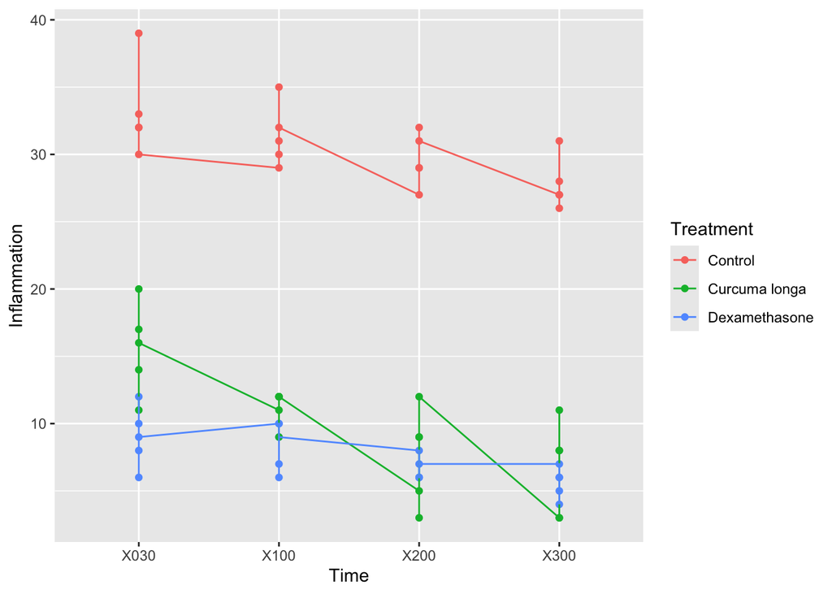

```r
ggplot(paw_long, aes(x = Time, y = Inflammation, color = Treatment, group = Treatment)) +  geom_point() + geom_line()
```

The Control group shows the highest inflammation across all time points. Curcuma longa and Dexamethasone reduce inflammation more effectively, with Dexamethasone being the most effective. The Non-parallel trend suggests a significant treatment × time interaction, meaning the effect of treatment changes over time.

4. Run a suitable mixed model repeated measures analysis. What is your conclusion from it, in the context of the data?

```r
paw.1 <- lmer(Inflammation ~ Treatment * Time + (1 | Animal.number), data = paw_long)
summary(paw.1)
```

```
Linear mixed model fit by REML ['lmerMod']
Formula: Inflammation ~ Treatment * Time + (1 | Animal.number)
   Data: paw_long

REML criterion at convergence: 232.6

Scaled residuals:
    Min      1Q  Median      3Q     Max
-2.1439 -0.4700  0.0173  0.4044  2.6254

Random effects:
 Groups        Name        Variance Std.Dev.
 Animal.number (Intercept) 2.522    1.588
 Residual                  3.561    1.887
Number of obs: 60, groups:  Animal.number, 15

Fixed effects:
                                Estimate Std. Error t value
(Intercept)                       33.200      1.103  30.099
TreatmentCurcuma longa           -17.600      1.560 -11.283
TreatmentDexamethasone           -24.200      1.560 -15.514
TimeX100                          -1.800      1.194  -1.508
TimeX200                          -3.600      1.194  -3.016
TimeX300                          -5.400      1.194  -4.525
TreatmentCurcuma longa:TimeX100   -2.600      1.688  -1.540
TreatmentDexamethasone:TimeX100    1.200      1.688   0.711
TreatmentCurcuma longa:TimeX200   -4.400      1.688  -2.607
TreatmentDexamethasone:TimeX200    1.200      1.688   0.711
TreatmentCurcuma longa:TimeX300   -3.600      1.688  -2.133
TreatmentDexamethasone:TimeX300    2.000      1.688   1.185

Correlation of Fixed Effects:
            (Intr) TrtmCl TrtmnD TmX100 TmX200 TmX300 TCl:TX1 TD:TX1 TCl:TX2
TrtmntCrcml -0.707
TrtmntDxmth -0.707  0.500
TimeX100    -0.541  0.383  0.383
TimeX200    -0.541  0.383  0.383  0.500
TimeX300    -0.541  0.383  0.383  0.500  0.500
TrtCl:TX100  0.383 -0.541 -0.271 -0.707 -0.354 -0.354
TrtmD:TX100  0.383 -0.271 -0.541 -0.707 -0.354 -0.354  0.500
TrtCl:TX200  0.383 -0.541 -0.271 -0.354 -0.707 -0.354  0.500   0.250
TrtmD:TX200  0.383 -0.271 -0.541 -0.354 -0.707 -0.354  0.250   0.500  0.500
TrtCl:TX300  0.383 -0.541 -0.271 -0.354 -0.354 -0.707  0.500   0.250  0.500
TrtmD:TX300  0.383 -0.271 -0.541 -0.354 -0.354 -0.707  0.250   0.500  0.250
            TD:TX2 TCl:TX3
TrtmntCrcml
TrtmntDxmth
TimeX100
TimeX200
TimeX300
TrtCl:TX100
TrtmD:TX100
TrtCl:TX200
TrtmD:TX200
TrtCl:TX300  0.250
TrtmD:TX300  0.500  0.500
```

5. Explore any possible interaction between treatment and time by finding simple effects of treatment (on inflammation) at each time point. Bear in mind that there are here *three* treatments. What does your simple effects analysis tell you about the reason for the significance (or not) of the interaction?

```r
paw_long %>%
  group_by(Time) %>%
  group_map(~summary(aov(Inflammation ~ Treatment, data = .x)))
```

```
[[1]]
            Df Sum Sq Mean Sq F value   Pr(>F)
Treatment    2   1565   782.5   83.84 8.88e-08 ***
Residuals   12    112     9.3
---
Signif. codes:  0 '***' 0.001 '**' 0.01 '*' 0.05 '.' 0.1 ' ' 1

[[2]]
            Df Sum Sq Mean Sq F value   Pr(>F)
Treatment    2 1574.8   787.4   229.3 2.75e-10 ***
Residuals   12   41.2     3.4
---
Signif. codes:  0 '***' 0.001 '**' 0.01 '*' 0.05 '.' 0.1 ' ' 1

[[3]]
            Df Sum Sq Mean Sq F value   Pr(>F)
Treatment    2 1690.0   845.0   145.7 3.83e-09 ***
Residuals   12   69.6     5.8
---
Signif. codes:  0 '***' 0.001 '**' 0.01 '*' 0.05 '.' 0.1 ' ' 1

[[4]]
            Df Sum Sq Mean Sq F value   Pr(>F)
Treatment    2 1572.1   786.1   136.3 5.62e-09 ***
Residuals   12   69.2     5.8
---
Signif. codes:  0 '***' 0.001 '**' 0.01 '*' 0.05 '.' 0.1 ' ' 1
```

6. Rerun your repeated measures analysis using `Manova`. Comment briefly on any differences you see. (You do not need to do any simple effects here, and you can stop with the interpretation as soon as you find a difference, if you find one. The output from `Manova` is long, but for this question, you can hand it all in.)

```r
paw_wide <- paw %>%
  select(Treatment, X030, X100, X200, X300)
paw_wide
```

| Treatment | X030 | X100 | X200 | X300 |
| --- | --- | --- | --- | --- |
| Control | 32 | 29 | 27 | 27 |
| Control | 33 | 31 | 29 | 28 |
| Control | 32 | 30 | 29 | 26 |
| Control | 39 | 35 | 32 | 31 |
| Control | 30 | 32 | 31 | 27 |
| Dexamethasone | 12 | 10 | 8 | 7 |
| Dexamethasone | 8 | 7 | 6 | 6 |
| Dexamethasone | 10 | 10 | 6 | 5 |
| Dexamethasone | 6 | 6 | 6 | 6 |
| Dexamethasone | 9 | 9 | 7 | 4 |

[output cut: 5 more lines]

```r
paw.2 <- manova(cbind(X030, X100, X200, X300) ~ Treatment, data = paw_wide)
summary(paw.2)
```

```
          Df Pillai approx F num Df den Df    Pr(>F)
Treatment  2 1.5064   7.6296      8     20 0.0001121 ***
Residuals 12
---
Signif. codes:  0 '***' 0.001 '**' 0.01 '*' 0.05 '.' 0.1 ' ' 1
```

## **Hemophilia**

7. Read in and display (some of) the data.

```r
my_url <- "http://ritsokiguess.site/datafiles/hemophilia_rrcov.csv"
hemophilia <- read_csv(my_url)
```

```r
hemophilia
```

| AHFactivity | AHFantigen | gr |
| --- | --- | --- |
| -0.0056 | -0.1657 | normal |
| -0.1698 | -0.1585 | normal |
| -0.3469 | -0.1879 | normal |
| -0.0894 | 0.0064 | normal |
| -0.1679 | 0.0713 | normal |
| -0.0836 | 0.0106 | normal |
| -0.1979 | -0.0005 | normal |
| -0.0762 | 0.0392 | normal |
| -0.1913 | -0.2123 | normal |
| -0.1092 | -0.1190 | normal |

[output cut: 65 more lines]

8. Make a suitable plot of the three variables in the dataset.

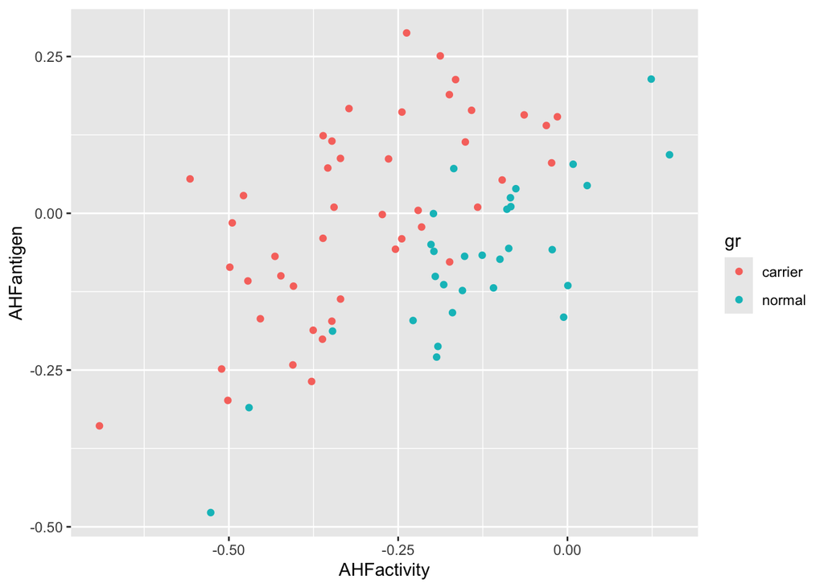

```r
ggplot(hemophilia, aes(x = AHFactivity, y = AHFantigen, color = gr)) + geom_point()
```

2 quantitative thus we use a scatter plot. I used color to distinguish between the two groups. The scatter plot suggests some overlap between carriers and normal individuals.

9. Run a discriminant analysis and display the results.

```r
hemophilia.1 <- lda(gr ~ AHFactivity + AHFantigen, data = hemophilia)
hemophilia.1
```

```
Call:
lda(gr ~ AHFactivity + AHFantigen, data = hemophilia)

Prior probabilities of groups:
carrier  normal
    0.6     0.4

Group means:
        AHFactivity   AHFantigen
carrier  -0.3079467 -0.005991111
normal   -0.1348700 -0.077856667

Coefficients of linear discriminants:
                  LD1
AHFactivity  9.032787
AHFantigen  -8.006605
```

Prior probabilities: 60% of women are carriers, 40% are normal. Carriers tend to have lower AHFactivity (-0.308 vs. -0.135). Normal individuals have lower AHFantigen (-0.078 vs. -0.006). AHFactivity (9.03) contributes positively thus higher values increase LD1. AHFantigen (-8.01) contributes negatively thus lower values increase LD1. LDA suggests AHFactivity is the strongest predictor for distinguishing between carriers and normal individuals.

10. What would make a woman have a high (positive) LD1 score?

Formula: LD1 = 9.0328 × AHFactivity - 8.0066 × AHFantigen.

A woman with higher AHFactivity and lower AHFantigen is more likely to be classified as normal, while lower AHFactivity and higher AHFantigen indicate carrier status.

11. Considering the goal of discriminant analysis, and looking at the plot you drew earlier, do the results of your discriminant analysis make sense? Explain briefly.

The goal of discriminant analysis is to find a linear combination of predictor variables (AHFactivity and AHFantigen) that best separates the two groups (carrier vs. normal). The scatter plot shows some overlap, meaning LDA classification may have errors. The LD1 coefficients confirm that AHFactivity is positively related to classification. The results are reasonable but not perfect. Some carriers and normal individuals have similar AHF values, making classification harder. Misclassification is expected due to overlap

12. Obtain the predicted group membership for all the women, and make a dataframe containing the original data, predicted group memberships, LD scores and posterior probabilities of being in each group.

```r
p <- predict(hemophilia.1)
d <- cbind(hemophilia,p)
d
```

|  | AHFactivity | AHFantigen | gr | class | posterior.carrier | posterior.normal | LD1 |
| --- | --- | --- | --- | --- | --- | --- | --- |
| 1 | -0.0056 | -0.1657 | normal | normal | 0.002777821 | 0.9972221788 | 3.154253438 |
| 2 | -0.1698 | -0.1585 | normal | normal | 0.069925591 | 0.9300744095 | 1.613422274 |
| 3 | -0.3469 | -0.1879 | normal | carrier | 0.581785885 | 0.4182141145 | 0.249109886 |
| 4 | -0.0894 | 0.0064 | normal | normal | 0.211268880 | 0.7887311203 | 1.019369250 |
| 5 | -0.1679 | 0.0713 | normal | carrier | 0.787615264 | 0.2123847355 | -0.209333159 |
| 6 | -0.0836 | 0.0106 | normal | normal | 0.204659576 | 0.7953404244 | 1.038131675 |
| 7 | -0.1979 | -0.0005 | normal | carrier | 0.659408658 | 0.3405913420 | 0.094557441 |
| 8 | -0.0762 | 0.0392 | normal | normal | 0.266856639 | 0.7331433609 | 0.875985407 |
| 9 | -0.1913 | -0.2123 | normal | normal | 0.043365453 | 0.9566345472 | 1.849972681 |
| 10 | -0.1092 | -0.1190 | normal | normal | 0.043849298 | 0.9561507020 | 1.844548281 |

[output cut: 65 more lines]

13. Make a graph that will tell you whether your linear discriminant(s) distinguish women with hemophilia from women without. What do you conclude? Explain briefly.

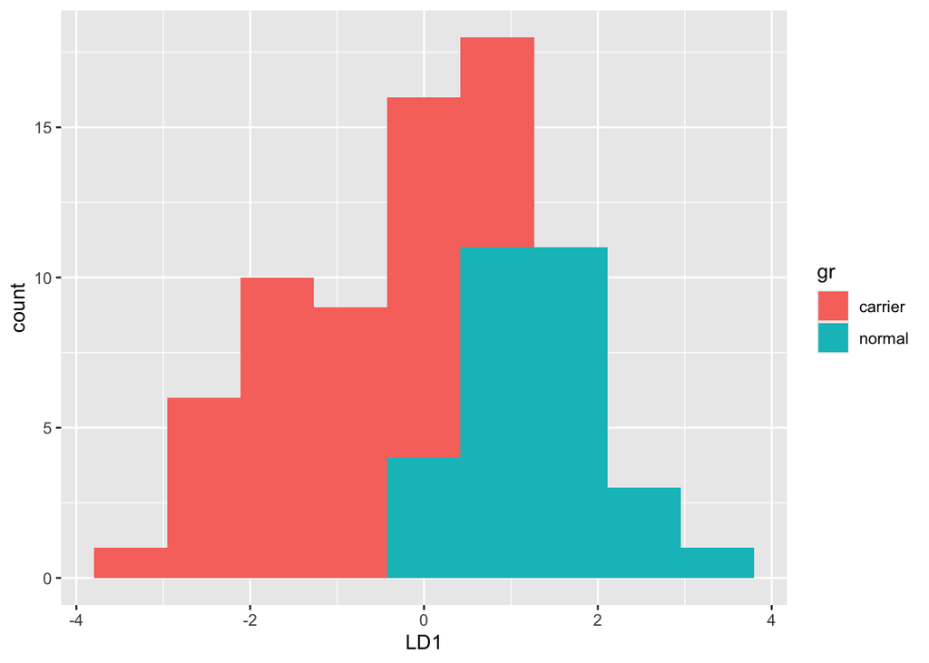

```r
ggplot(d, aes(x = LD1, fill = gr)) + geom_histogram(bins = 9)
```

The histogram of LD1 scores shows partial separation, with some overlap between groups. Normal individuals have higher LD1 scores, while carriers have lower LD1 scores. Misclassifications occur where the two distributions overlap, but LDA still provides useful differentiation.

14. Make a table showing how many women are correctly and incorrectly classified. Does this make sense given your graph in the previous question? Explain briefly.

```r
d %>% count(gr, class) %>%
  pivot_wider(names_from = class, values_from = n, values_fill = 0)
```

| gr | carrier | normal |
| --- | --- | --- |
| carrier | 38 | 7 |
| normal | 4 | 26 |

15. Find a woman in the dataset that was difficult for the discriminant analysis to classify. (Hint: posterior probabilities.) Where on your graph of Question 8 does that woman fall? Explain briefly why that makes sense.

```r
d %>% filter(gr != class)
```

|  | AHFactivity | AHFantigen | gr | class | posterior.carrier | posterior.normal | LD1 |
| --- | --- | --- | --- | --- | --- | --- | --- |
| 3 | -0.3469 | -0.1879 | normal | carrier | 0.5817859 | 0.4182141 | 0.24910989 |
| 5 | -0.1679 | 0.0713 | normal | carrier | 0.7876153 | 0.2123847 | -0.20933316 |
| 7 | -0.1979 | -0.0005 | normal | carrier | 0.6594087 | 0.3405913 | 0.09455744 |
| 17 | -0.4702 | -0.3099 | normal | carrier | 0.6508970 | 0.3491030 | 0.11217302 |
| 35 | -0.1326 | 0.0097 | carrier | normal | 0.3950333 | 0.6049667 | 0.60273106 |
| 58 | -0.3778 | -0.2682 | carrier | normal | 0.3898340 | 0.6101660 | 0.61292712 |
| 62 | -0.0149 | 0.1539 | carrier | normal | 0.4425710 | 0.5574290 | 0.51133770 |
| 63 | -0.0312 | 0.1400 | carrier | normal | 0.4616103 | 0.5383897 | 0.47539508 |
| 64 | -0.1740 | -0.0776 | carrier | normal | 0.2457624 | 0.7542376 | 0.92775026 |
| 67 | -0.0964 | 0.0531 | carrier | normal | 0.4055580 | 0.5944420 | 0.58223131 |

[output cut: 1 more lines]

A woman in the dataset with AHFactivity = -0.3469 and AHFantigen = -0.1879 was misclassified as a carrier when she was actually normal. Her posterior probabilities were 0.5818 for carrier and 0.4182 for normal, indicating that the model was uncertain but slightly leaned toward the incorrect classification. From the scatter plot, this individual falls within the overlapping region where some normal individuals are close to carriers, making classification difficult. Additionally, her LD1 score = 0.249 places her near the decision boundary in the histogram (Question 13), further confirming why the model struggled to classify her correctly. This misclassification is expected, as linear discriminant analysis is less effective when groups overlap significantly. The close posterior probabilities and near-boundary LD1 score suggest ambiguity, making this a borderline case.

## Conclusion

This analysis highlights:

- The use of mixed models and MANOVA to analyze longitudinal treatment data
- The strengths and limitations of LDA in binary classification problems
- Real-world handling of classification uncertainty and subject-level variability

**Skills Demonstrated:**

- Statistical modeling with `lmer`, `aov`, and `lda`
- Data visualization using `ggplot2`
- Model interpretation and communication

**Tools Used:** R, tidyverse, lme4, MASS, car, MVTests